# Milestone Report

Markus Heuchert

March, 28th 2015

This report was made as part of the Coursera Data Science Specialization Capstone Project. The goal of this last course is to create a n-gram model that is able to predict the next words based on previously typed in words.

Data in four different languages were given to the students:

- English
- German
- Finnish
- Russian

For each language, there are 3 TXT-Files containing blog, news and twitter data. Summarized more than 1.4 GB of data. After doing some reading concerning the analysis of text data, the first task was to get the data into R, clean it and structure it properly for later analysis.

After this some exploratory data analysis was made to get an overview of this massive dataset.

The packages used here are:

```r
options( java.parameters = "-Xmx4g" )
library("tm")
library("qdap")
library("RWeka")
library("SnowballC")
library("wordcloud")
```

Note that we only read the first 10000 lines per file due to the large data set.

```r
directory_source_us <- DirSource(paste0(getwd(),"/en_US"), encoding = "UTF-8")
connection <- file(directory_source_us$filelist[1])
blogs <- readLines(connection, n=10000)
connection <- file(directory_source_us$filelist[2])
news <- readLines(connection,n=10000)
connection <- file(directory_source_us$filelist[3])
twitter <- readLines(connection,n=10000)
close(connection)
file.info(directory_source_us$filelist)[1]
```

```
##                                                                      size
## /Volumes/Nifty/coursera final /capstone/en_US/en_US.blogs.txt   210160014
## /Volumes/Nifty/coursera final /capstone/en_US/en_US.news.txt    205811889
## /Volumes/Nifty/coursera final /capstone/en_US/en_US.twitter.txt 167105338
```

We see that the blogs file is the largest (210 MB) followed by news (205MB) and twitter (167MB). Using system commands, we can find out the line and word count for the files.

```r
system("wc -w -l ./en_US/*.txt", intern =T)
```

```
## [1] "  899288 37334690 ./en_US/en_US.blogs.txt"
## [2] " 1010242 34372720 ./en_US/en_US.news.txt"
## [3] " 2360148 30374206 ./en_US/en_US.twitter.txt"
## [4] " 4269678 102081616 total"
```

The blogs file for example has 899288 lines and 37334690 words.

### Create Sample

We randomly choose 5000 entries of each dataset to create our sample. Then a corpus is created.

```r
set.seed(192)
sample <- c(blogs[sample(length(blogs),size = 5000,replace = FALSE)], news[sample(length(news),size=5000, replace=FALSE)], twitter[sample(length(twitter),size=5000,replace=FALSE)])
rm(news) # always keep it clean...
rm(blogs)
rm(twitter)
corpus <- Corpus(VectorSource(sample))
```

### Cleaning

Cleaning the data is a very important part of text mining. The tm-package offers some functions to help us with this task. I’ve created a function to perform the tasks (see Apendix) . First all numbers are removed. All characters are made to lower case. In the English language this is not a big deal but other languages with other rules (to capitalize nouns like in German for example) one need to think about this step carefully. However, we concentrate on the English data set here. Stopwords, provided by the tm-package, are reduced for the given language. Whitespaces are also removed by another function from the tm package.

For this report I did not perform stemming because I want to use word clouds to illustrate important n-grams later.

```r
corpus_clean <-getandclean(corpus, "english")
```

### Profanity

One task was to remove profanity in the data set. I used a txt-file from http://www.cs.cmu.edu/~biglou/resources/bad-words.txt to filter 1800 of them out.

```r
connection <- file("badwords.txt")
badwords <- readLines(connection)
close(connection)

badwordssource <- VectorSource(badwords)
corpus_superclean <- tm_map(corpus_clean, removeWords, badwordssource)
```

This completes this cleaning phase. I admit that there are better ways to clean the data set based on the structure of the language (replace ’ll -> _will , ’d -> should etc). Given that I only speak two of the four languages provided, I did not include such logic to have my model based on a data set of equal quality.

Maybe I will try to rebuild proper words after making the prediction, so that before returning the word to the user a logic will transform possible word fragments into proper language.

### Tokenization

Now the RWeka package is used to create the different n-grams of the sample corpus. Before that we separate by sentence because our goal is to predict the next word IN a sentence.

```r
corpus_superclean <-  tm_map(corpus_superclean, function(x) gsub("[!?.]+",".",x))
 df_superclean <- as.data.frame(corpus_superclean, stringsAsFactors = FALSE)
splitted <- strsplit(df_superclean$text,'\\.')
splitted <- unlist(splitted)
corpus <-Corpus(VectorSource(splitted))
corpus <- tm_map(corpus, removePunctuation)
df_superclean <- as.data.frame(corpus, stringsAsFactors = FALSE)
NGramTokenizer(df_superclean$text, Weka_control(min=1,max=1))->ng1
NGramTokenizer(df_superclean$text, Weka_control(min=2,max=2))->ng2
NGramTokenizer(df_superclean$text, Weka_control(min=3,max=3))->ng3
NGramTokenizer(df_superclean$text, Weka_control(min=4,max=4))->ng4
```

We create a contigency table and sort it to get an overview of the n-grams and their counts in the sample.

### Frequencies

For the 1-Grams, or simple word counts, we see that the letters m and s are in the top 20. This is likely due to the fact that I’m or he’s resulting in splitting of these characters.

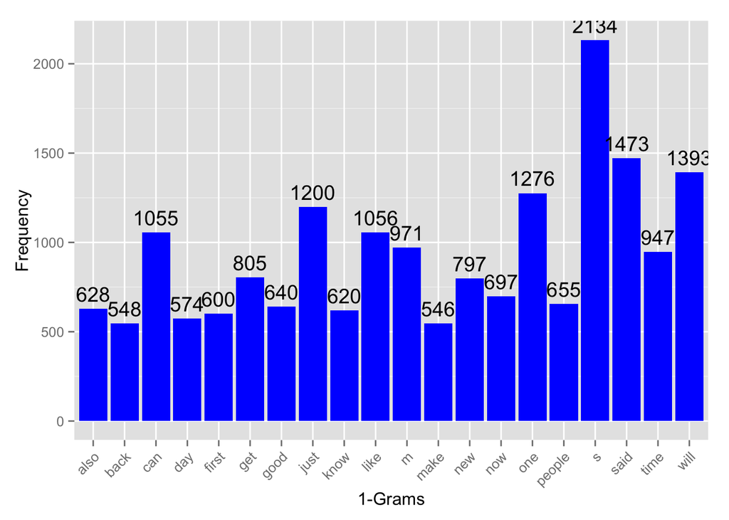

Lets use a word cloud for the 2- and 3-grams.

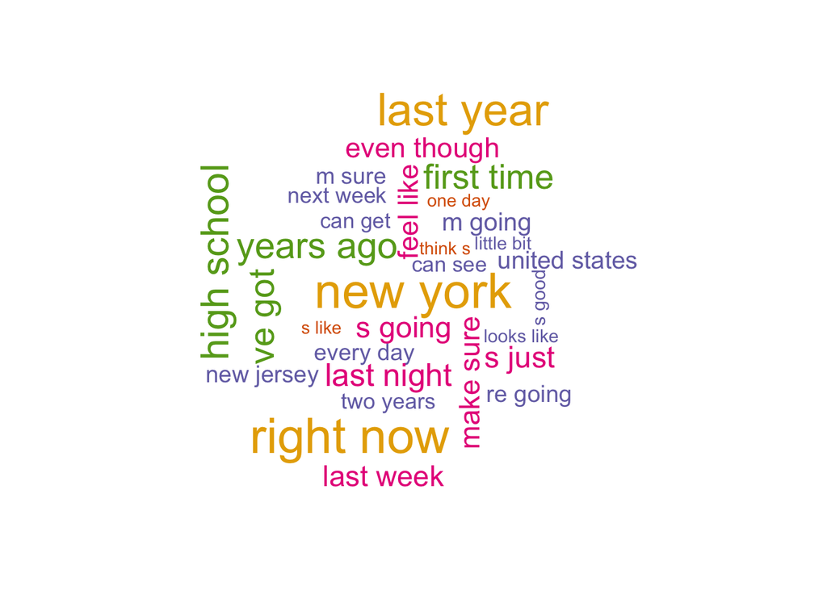

```r
wordcloud(tab_ng2[,1],tab_ng2[,2],max.words = 30,scale = c(2.5, 0.1),colors=brewer.pal(6,"Dark2"))
```

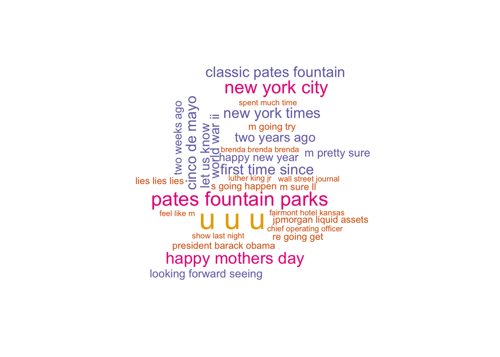

```r
wordcloud(tab_ng3[,1],tab_ng3[,2],max.words = 30,scale = c(2.5, 0.1),colors=brewer.pal(6,"Dark2"))
```

Our sample is a little bit too small for extracting 4-grams, as we can see in the top 5 and especially their frequencies.

```r
head(tab_ng4)
```

```
##                                      ng4 Freq
## 138839                           u u u u    9
## 22435       classic pates fountain parks    8
## 42307         fairmont hotel kansas city    4
## 71234                lies lies lies lies    4
## 78915              martin luther king jr    4
## 7059   arrested outstanding scott county    3
```

### Quantiles

We know that the data set is fairly large, too large to use all of its data. We probably need to shrink the ngram data set. We need to keep in mind that it is just a sample, so the numbers will look different on the whole data set. Still we can get a first impression.

```r
quantile(tab_ng2$Freq, seq(0.9,1,0.025))
```

```
##   90% 92.5%   95% 97.5%  100%
##     1     1     2     2    87
```

```r
quantile(tab_ng3$Freq, seq(0.9,1,0.025))
```

```
##   90% 92.5%   95% 97.5%  100%
##     1     1     1     1    17
```

This means that over 90% of the extracted 2, 3-grams only appear once in the data set.

### Next up, thoughts

Obviously the model creation will be the next big milestone. It will be based on the full 2,3 and 4-grams based on the complete data set. Subsets will be created and most likely entries with a count less than 2 (or an even higher number) will be excluded due to performance issues. Due to computational effort, it will be likely that I will split the models for the type of document my data product works on (blogs, news, tweets) as well as the language. In a real application, these could be infered by the keyboard settings or context used in.

A count-based approach of the ngrams will be the basis of the prediction. The backup-model (if no n-gram is found) will try to find hits with different spellings or stemming the input.

Also the English language has some special written notations or abbreviations. Examples are

- I’m
- He’s
- She’d
- They’ll
- can’t
- don’t

All of these have in common that they use the char “’” to shorten some words. The algorithm should take care of these cases because removing this char in general after taking care of the splitting due to end of sentences, would create a lot of empty grams.

Another thing to take into account are smileys that use a colon combined with a letter (i.e. :D :P :S). An easy way would be to eliminate all single letters after the removal of punctuation. However, an exception for the letter I should be made.

### Appendix

Function for getting and cleaning the data

```r
getandclean <- function(txt, lang){

  data <- tm_map(txt, removeNumbers)
  data <- tm_map(data, content_transformer(tolower))
  data <- tm_map(data, removeWords, stopwords(lang))
  data <- tm_map(data, stripWhitespace)
  data}
```